# Comparing Deep Learning Models on MNIST: A Performance and Execution Time Analysis

## Abstract

In this notebook I will give an analysis and comparison of deep learning models on the MNIST dataset. Initially, it outlines the process of loading and preprocessing data, followed by the definition and training of two models: Basic Neural Network (BNN) and Convolutional Neural Network (CNN). We will then look at hyperparameter tuning, exploring the impact of learning rates, batch sizes, epochs and activation functions on model performance and training time. Through comparative graphs, this tutorial will show how these hyperparameters influence accuracy and execution time, providing insights into optimizing neural network training for enhanced performance on MNIST classification.

## Contents

1. Learning Objectives: Goals and skills to be gained from this tutorial

2. Step 1: Import necessary libraries

3. Step 2: Load and preprocess the MNIST dataset

4. Step 3: Define multiple deep learning models

5. Step 4: Train the models and measure their execution time

6. Step 5: Plot performance and execution time

7. Experimentation with tweaking of hyperparameters:  
- Adjusting the batch size  
- Adjusting the learning rate  
- Modifying the number of training epochs  
- Experimentation with different activation functions

9. Pros and Cons of the Tutorial

10. References

### Learning Objectives

By following this tutorial notebook, learners will achieve the following objectives:

- Understand the Basics of PyTorch: Learn how to use PyTorch for deep learning tasks, including the manipulation of tensors, model definition, and the use of automatic differentiation.
- Load and Preprocess Dataset: Gain proficiency in loading the MNIST dataset using torchvision, preprocessing it with transforms, and preparing it for model training using DataLoader.
- Implement Neural Network Models: Develop the skills to define and implement two types of neural network architectures—Basic Neural Network (BNN) and Convolutional Neural Network (CNN)—using PyTorch's nn module.
- Understand Forward and Backward Propagation: Learn the concepts of forward and backward propagation through practical application, understanding how data flows through the network and how gradients are computed for optimization.
- Perform Model Training and Evaluation: Master the steps involved in training a neural network, including setting up a loss function, choosing an optimizer, and iteratively adjusting model weights based on training data. Additionally, learn how to evaluate model performance on a test dataset to gauge accuracy.
- Experiment with Hyperparameters: Acquire the ability to tune key hyperparameters such as learning rate, batch size, number of training epochs, activation functions, and understand their impact on model performance and training dynamics.
- Visualize Training Results: Learn to use Matplotlib for generating graphs that compare model performances, specifically focusing on training time and accuracy, facilitating a deeper understanding of model behavior and optimization.

## Step 1: Import necessary libraries

```python
import torch
import torchvision
import torchvision.transforms as transforms
import matplotlib.pyplot as plt
import numpy as np
import time
from torch import nn, optim
```

### Check if GPU is available and set device accordingly

```python
# setting device on GPU if available, else CPU
device = torch.device("cuda" if torch.cuda.is_available() else "cpu")
#https://stackoverflow.com/questions/48152674/how-do-i-check-if-pytorch-is-using-the-gpu
```

## Step 2: Load and preprocess the MNIST dataset

```python
transform = transforms.Compose([transforms.ToTensor(), transforms.Normalize((0.5,), (0.5,))])
#MNIST Images are greyscale so only one channel required for both mean and standard deviation -
#if image was coloured as in CIFAR dataset, 3 channels would be used
#Standard deviation and mean are both set to 0.5, this will normalize the image in the range [-1,1]
#https://discuss.pytorch.org/t/understanding-transform-normalize/21730
```

```python
trainset = torchvision.datasets.MNIST(
    root='./data',
    train=True,
    download=True,
    transform=transform
)


trainloader = torch.utils.data.DataLoader(trainset, batch_size=64, shuffle=True)

testset = torchvision.datasets.MNIST(
    root='./data',
    train=False,
    download=True,
    transform=transform
)



testloader = torch.utils.data.DataLoader(testset, batch_size=64, shuffle=False)

#https://www.youtube.com/watch?v=vBlO87ZAiiw&t=507s
#This tutorial shows how I can use a data loader to test and train in batches
#I set batch size to 64 to start with as it seems like the best middle ground
#Higher batch sizes would train faster but may lead to slightly lower accuracy due to less frequent parameter updates
#Can experiment with 128 or 256
#Lower batch sizes, though they would lead to higher accuracy, would train slower
#Can experiment with 32 or 16
```

This section loads the MNIST dataset and applies preprocessing steps. The 'transform' variable specifies that images should be converted to PyTorch tensors and normalized. The MNIST dataset is split into training and test sets, and DataLoaders are used to iterate over these datasets in batches of 64 images during the training and evaluation phases.

```python
trainset
```

```
Dataset MNIST
    Number of datapoints: 60000
    Root location: ./data
    Split: Train
    StandardTransform
Transform: Compose(
               ToTensor()
               Normalize(mean=(0.5,), std=(0.5,))
           )
```

```python
testset
```

```
Dataset MNIST
    Number of datapoints: 10000
    Root location: ./data
    Split: Test
    StandardTransform
Transform: Compose(
               ToTensor()
               Normalize(mean=(0.5,), std=(0.5,))
           )
```

```python
trainset.data.shape
```

```
torch.Size([60000, 28, 28])
```

```python
trainloader
```

```
<torch.utils.data.dataloader.DataLoader at 0x235ee7b85c8>
```

## Step 3: Define multiple deep learning models

```python
class BNN(nn.Module):#simple multilayer perceptron - basic neural network
    def __init__(self):
        super(BNN, self).__init__()
        self.fc = nn.Sequential(
            nn.Linear(28*28, 128),
            #The first layer takes the flattened input images (originally 28x28 pixels,
            #flattened to a 784-dimensional 1d vector) and maps them to a hidden layer with 128 neurons (arbitrarily chosen),
            #followed by a ReLU activation function for introducing non-linearity.
            nn.ReLU(),
            nn.Linear(128, 64),
            #The second layer reduces the dimensionality further from 128 to 64 neurons
            nn.ReLU(),
            nn.Linear(64, 10)
            #The final layer maps these 64 features to 10 outputs, corresponding to the
            #10 possible classes (digits 0-9) in the MNIST dataset.
        )
        #https://pytorch.org/tutorials/beginner/basics/buildmodel_tutorial.html

    def forward(self, x):
        x = x.view(x.shape[0], -1)
        #flattens the input images except for the batch dimension, making it suitable
        #for processing through fully connected layers
        return self.fc(x)

class CNN(nn.Module):
    def __init__(self):
        super(CNN, self).__init__()
        self.conv = nn.Sequential(#As shown in slides on CNN, my structure is Conv->ReLU->Pooling x2
            nn.Conv2d(1, 32, 3, 1),
            nn.ReLU(),
            nn.MaxPool2d(2),
            nn.Conv2d(32, 64, 3, 1),
            nn.ReLU(),
            nn.MaxPool2d(2)
        )
        self.fc_input_size = 5*5*64
        self.fc = nn.Sequential(
            nn.Linear(self.fc_input_size, 128),
            nn.ReLU(),
            nn.Linear(128, 10)
        )

    def forward(self, x):
        x = self.conv(x)
        x = x.view(x.size(0), -1)  # Flatten the output for the fully connected layer
        return self.fc(x)
```

Classes BNN and CNN are defined to represent different neural network architectures. BNN is a simple fully connected neural network, while CNN is a convolutional neural network that can capture spatial hierarchies in images.

### Define a function to train and evaluate models

```python
def train_and_evaluate(model, trainloader, testloader, device, lr, epochs):
    criterion = nn.CrossEntropyLoss()
    optimizer = optim.Adam(model.parameters(), lr=lr) # also from https://www.youtube.com/watch?v=vBlO87ZAiiw&t=507s
    #https://pytorch.org/docs/stable/optim.html
    #here the learning rate is defined
    #can tweak this to 0.01, 0.005, 0.0005
    model.to(device)

    # Train the model
    model.train()
    start_time = time.time()
    for epoch in range(epochs): # Train for 10 epochs for simplicity - can be tweaked for hyperparameter experimentation
        for images, labels in trainloader:
            images, labels = images.to(device), labels.to(device)
            optimizer.zero_grad()
            output = model(images)
            loss = criterion(output, labels)
            loss.backward()
            optimizer.step()
    training_time = time.time() - start_time

    #https://stackoverflow.com/questions/62833157/cnn-model-using-pytorch

    # Evaluate the model
    model.eval()
    correct = 0
    total = 0
    with torch.no_grad():
        for images, labels in testloader:
            images, labels = images.to(device), labels.to(device)
            outputs = model(images)
            _, predicted = torch.max(outputs.data, 1)
            total += labels.size(0)
            correct += (predicted == labels).sum().item()
    accuracy = 100 * correct / total

    return training_time, accuracy
```

This function uses the time module to measure the difference between start and end of training in seconds and output that as training time.

For measuring accuracy, a loop iterates over the test dataset without tracking gradients (to save memory and computations), and the model's predictions are compared to the actual labels.

The number of correct predictions is accumulated during the loop, and at the end, the accuracy is computed as the percentage of correct predictions out of the total number of examples in the test dataset

## Step 4: Train the models and measure their execution time

```python
models = [BNN(), CNN()]
results = {}
def store_results(model_name, hyperparameter_values, training_time, accuracy):
    results[f"{model_name} - {hyperparameter_values}"] = {'Time': training_time, 'Accuracy': accuracy}

for model in models:
    model_name = type(model).__name__
    hyperparameter_values = "Base"
    print(f"Training {model_name}...")
    training_time, accuracy = train_and_evaluate(model, trainloader, testloader, device, 0.001, 10)
    store_results(model_name, hyperparameter_values, training_time, accuracy)
    print(f"{model_name} - Time: {training_time:.2f} s, Accuracy: {accuracy:.2f}%")
```

```
Training BNN...
BNN - Time: 92.58 s, Accuracy: 97.48%
Training CNN...
CNN - Time: 252.36 s, Accuracy: 99.18%
```

## Step 5: Plot performance and execution time

```python
def plotgraph():
    fig, (ax1, ax2) = plt.subplots(1, 2, figsize=(18, 10))  # Create 2 subplots

    # Extract model names and hyperparameter info (optional for x-axis labels)
    x_labels = results.keys()

    #https://www.datacamp.com/tutorial/line-plots-in-matplotlib-with-python#:~:text=Matplotlib%20Line%20Plots%20with%20Twin%20Axes,-There%20might%20be&text=To%20create%20a%20line%20plot%20with%20twin%20axes%2C%20we%20need,axis%20as%20the%20original%20plot.

    # Plot execution time
    ax1.plot(x_labels, [result['Time'] for result in results.values()], color='g', label='Training Time')
    ax1.set_xlabel('Model (Hyperparameters)')
    ax1.set_ylabel('Training Time (s)', color='g')
    ax1.set_title('Training Time Comparison')
    ax1.tick_params(axis='x', rotation=45)

    # Plot accuracy
    ax2.plot(x_labels, [result['Accuracy'] for result in results.values()], color='b', marker='o', linestyle='--', label='Accuracy')
    ax2.set_xlabel('Model (Hyperparameters)')
    ax2.set_ylabel('Accuracy (%)', color='b')
    ax2.set_title('Accuracy Comparison')

    # Customize plot appearance
    plt.xticks(rotation=45, ha='right')#Implemented to prevent future labels overlapping
    lines1, labels1 = ax1.get_legend_handles_labels()
    ax1.legend(lines1, labels1, loc='upper left')
    lines2, labels2 = ax2.get_legend_handles_labels()
    ax2.legend(lines2, labels2, loc='upper left')
    plt.tight_layout()
    plt.show()
```

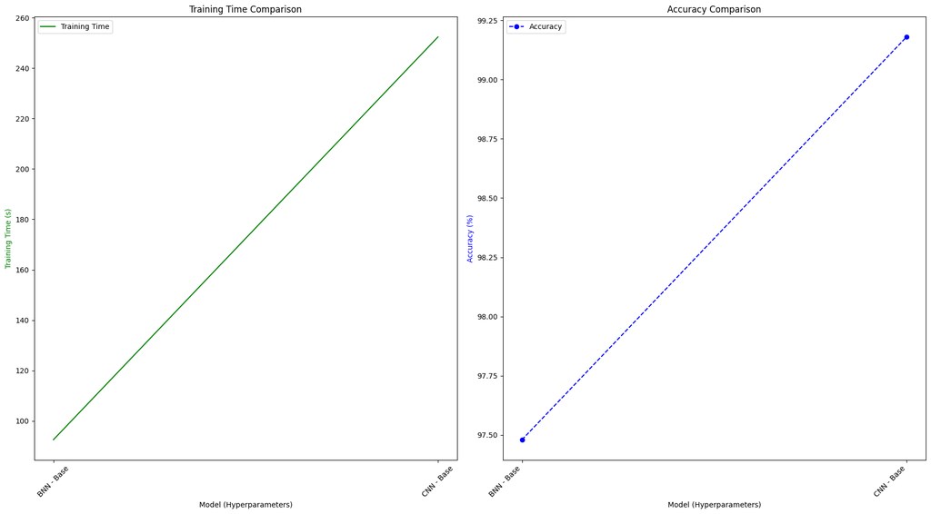

```python
plotgraph()
```

## Experimentation with tweaking of hyperparameters

## Experimentation with increased Batch Size

```python
trainset = torchvision.datasets.MNIST(
    root='./data',
    train=True,
    download=True,
    transform=transform
)


trainloader = torch.utils.data.DataLoader(trainset, batch_size=256, shuffle=True)

testset = torchvision.datasets.MNIST(
    root='./data',
    train=False,
    download=True,
    transform=transform
)



testloader = torch.utils.data.DataLoader(testset, batch_size=256, shuffle=False)
```

```python
for model in models:
    model_name = type(model).__name__
    hyperparameter_values = "Inc Batch"
    print(f"Training {model_name}...")
    training_time, accuracy = train_and_evaluate(model, trainloader, testloader, device, 0.001, 10)
    store_results(model_name, hyperparameter_values, training_time, accuracy)
    print(f"{model_name} - Time: {training_time:.2f} s, Accuracy: {accuracy:.2f}%")
```

```
Training BNN...
BNN - Time: 84.59 s, Accuracy: 97.82%
Training CNN...
CNN - Time: 226.40 s, Accuracy: 99.28%
```

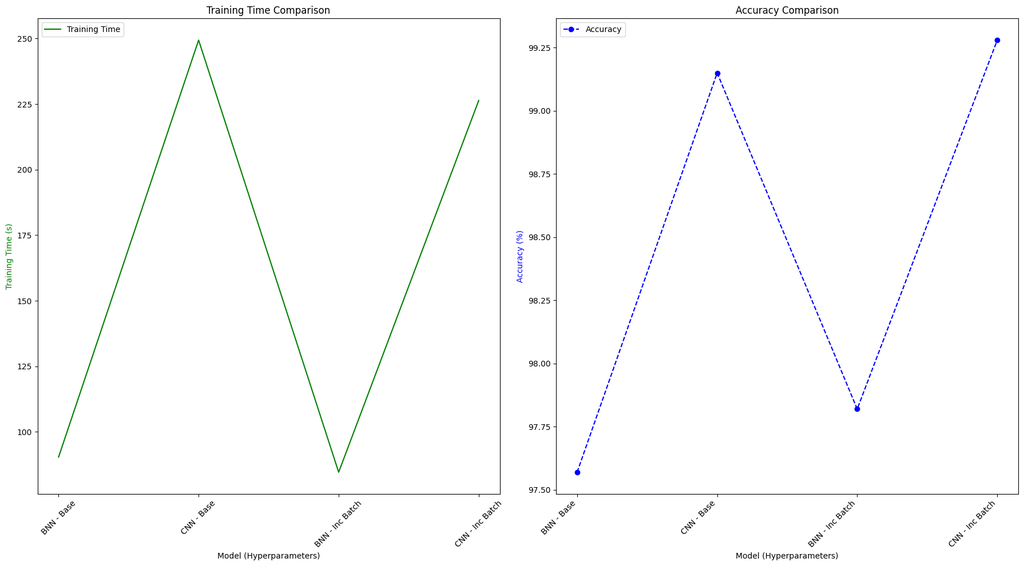

```python
plotgraph()
```

## Experimentation with decreased Batch Size

```python
trainset = torchvision.datasets.MNIST(
    root='./data',
    train=True,
    download=True,
    transform=transform
)


trainloader = torch.utils.data.DataLoader(trainset, batch_size=16, shuffle=True)

testset = torchvision.datasets.MNIST(
    root='./data',
    train=False,
    download=True,
    transform=transform
)



testloader = torch.utils.data.DataLoader(testset, batch_size=16, shuffle=False)
```

```python
for model in models:
    model_name = type(model).__name__
    hyperparameter_values = "Decr Batch"
    print(f"Training {model_name}...")
    training_time, accuracy = train_and_evaluate(model, trainloader, testloader, device, 0.001, 10)
    store_results(model_name, hyperparameter_values, training_time, accuracy)
    print(f"{model_name} - Time: {training_time:.2f} s, Accuracy: {accuracy:.2f}%")
```

```
Training BNN...
BNN - Time: 121.49 s, Accuracy: 96.66%
Training CNN...
CNN - Time: 291.56 s, Accuracy: 99.00%
```

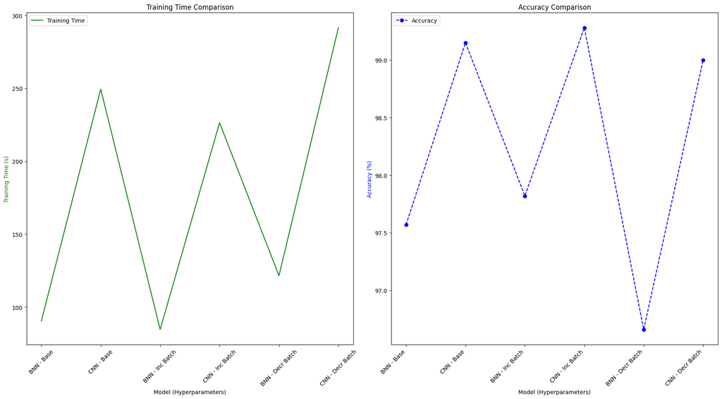

```python
plotgraph()
```

## Experimentation with learning rate

**Start by resetting batch size to base - run 4th code block**

## Increase Learning Rate

```python
for model in models:
    model_name = type(model).__name__
    hyperparameter_values = "Inc LR"
    print(f"Training {model_name}...")
    training_time, accuracy = train_and_evaluate(model, trainloader, testloader, device, 0.01, 10)#Changed LR
    store_results(model_name, hyperparameter_values, training_time, accuracy)
    print(f"{model_name} - Time: {training_time:.2f} s, Accuracy: {accuracy:.2f}%")
```

```
Training BNN...
BNN - Time: 121.71 s, Accuracy: 91.63%
Training CNN...
CNN - Time: 273.80 s, Accuracy: 97.41%
```

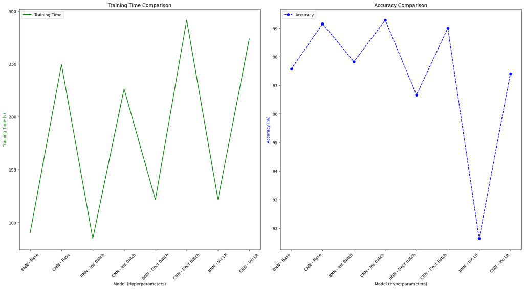

```python
plotgraph()
```

## Decrease Learning Rate

```python
for model in models:
    model_name = type(model).__name__
    hyperparameter_values = "Decr LR"
    print(f"Training {model_name}...")
    training_time, accuracy = train_and_evaluate(model, trainloader, testloader, device, 0.0005, 10)#Changed LR
    store_results(model_name, hyperparameter_values, training_time, accuracy)
    print(f"{model_name} - Time: {training_time:.2f} s, Accuracy: {accuracy:.2f}%")
```

```
Training BNN...
BNN - Time: 121.51 s, Accuracy: 96.59%
Training CNN...
CNN - Time: 284.81 s, Accuracy: 98.56%
```

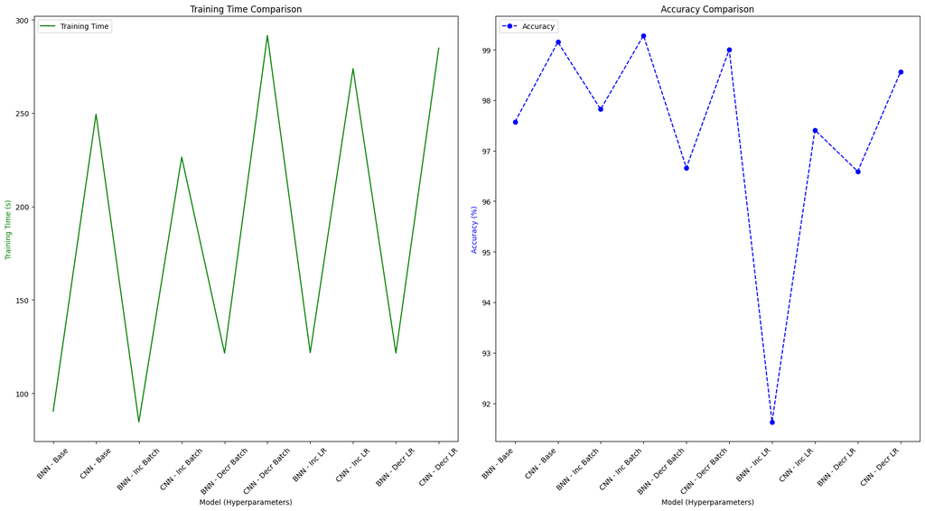

```python
plotgraph()
```

## Experimentation with number of epochs

## Increase Epochs

```python
for model in models:
    model_name = type(model).__name__
    hyperparameter_values = "Inc Epoch"
    print(f"Training {model_name}...")
    training_time, accuracy = train_and_evaluate(model, trainloader, testloader, device, 0.001, 20)
    store_results(model_name, hyperparameter_values, training_time, accuracy)
    print(f"{model_name} - Time: {training_time:.2f} s, Accuracy: {accuracy:.2f}%")
```

```
Training BNN...
BNN - Time: 256.40 s, Accuracy: 96.62%
Training CNN...
CNN - Time: 593.82 s, Accuracy: 98.71%
```

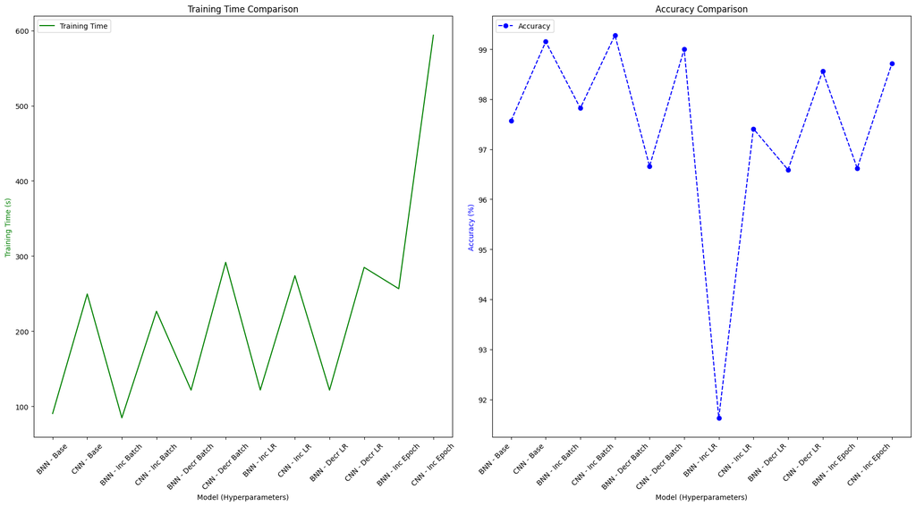

```python
plotgraph()
```

## Decrease Epochs

```python
for model in models:
    model_name = type(model).__name__
    hyperparameter_values = "Decr Epoch"
    print(f"Training {model_name}...")
    training_time, accuracy = train_and_evaluate(model, trainloader, testloader, device, 0.001, 5)
    store_results(model_name, hyperparameter_values, training_time, accuracy)
    print(f"{model_name} - Time: {training_time:.2f} s, Accuracy: {accuracy:.2f}%")
```

```
Training BNN...
BNN - Time: 60.31 s, Accuracy: 96.59%
Training CNN...
CNN - Time: 139.56 s, Accuracy: 98.66%
```

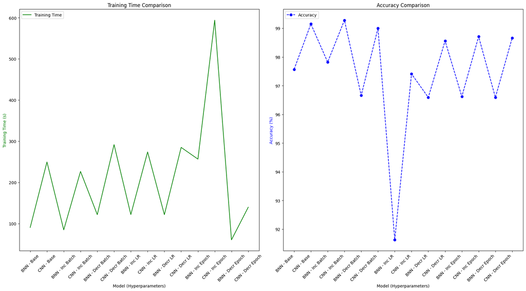

```python
plotgraph()
```

## Experimentation with Activation Functions

```python
class BNN(nn.Module):#simple multilayer perceptron - basic neural network
    def __init__(self):
        super(BNN, self).__init__()
        self.fc = nn.Sequential(
            nn.Linear(28*28, 128),
            nn.LeakyReLU(),
            nn.Linear(128, 64),
            #The second layer reduces the dimensionality further from 128 to 64 neurons
            nn.LeakyReLU(),
            nn.Linear(64, 10)
            #The final layer maps these 64 features to 10 outputs, corresponding to the
            #10 possible classes (digits 0-9) in the MNIST dataset.
        )
        #https://pytorch.org/tutorials/beginner/basics/buildmodel_tutorial.html

    def forward(self, x):
        x = x.view(x.shape[0], -1)
        #flattens the input images except for the batch dimension, making it suitable
        #for processing through fully connected layers
        return self.fc(x)

class CNN(nn.Module):
    def __init__(self):
        super(CNN, self).__init__()
        self.conv = nn.Sequential(#As shown in slides on CNN, my structure is Conv->ReLU->Pooling x2
            nn.Conv2d(1, 32, 3, 1),
            nn.LeakyReLU(),
            nn.MaxPool2d(2),
            nn.Conv2d(32, 64, 3, 1),
            nn.LeakyReLU(),
            nn.MaxPool2d(2)
        )
        self.fc_input_size = 5*5*64
        self.fc = nn.Sequential(
            nn.Linear(self.fc_input_size, 128),
            nn.LeakyReLU(),
            nn.Linear(128, 10)
        )

    def forward(self, x):
        x = self.conv(x)
        x = x.view(x.size(0), -1)  # Flatten the output for the fully connected layer
        return self.fc(x)
```

```python
for model in models:
    model_name = type(model).__name__
    hyperparameter_values = "LReLU"
    print(f"Training {model_name}...")
    training_time, accuracy = train_and_evaluate(model, trainloader, testloader, device, 0.001, 10)
    store_results(model_name, hyperparameter_values, training_time, accuracy)
    print(f"{model_name} - Time: {training_time:.2f} s, Accuracy: {accuracy:.2f}%")
```

```
Training BNN...
BNN - Time: 122.23 s, Accuracy: 96.42%
Training CNN...
CNN - Time: 303.80 s, Accuracy: 98.72%
```

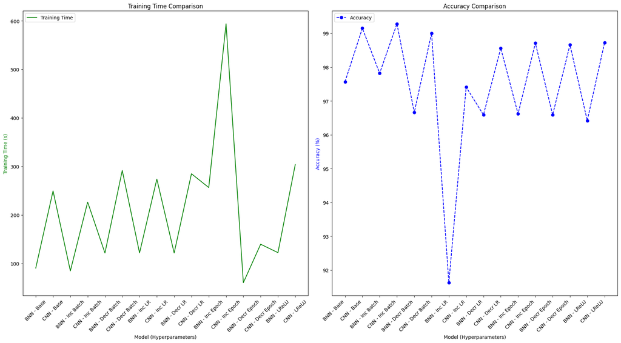

```python
plotgraph()
```

```python
class BNN(nn.Module):#simple multilayer perceptron - basic neural network
    def __init__(self):
        super(BNN, self).__init__()
        self.fc = nn.Sequential(
            nn.Linear(28*28, 128),
            nn.Sigmoid(),
            nn.Linear(128, 64),
            #The second layer reduces the dimensionality further from 128 to 64 neurons
            nn.Sigmoid(),
            nn.Linear(64, 10)
            #The final layer maps these 64 features to 10 outputs, corresponding to the
            #10 possible classes (digits 0-9) in the MNIST dataset.
        )
        #https://pytorch.org/tutorials/beginner/basics/buildmodel_tutorial.html

    def forward(self, x):
        x = x.view(x.shape[0], -1)
        #flattens the input images except for the batch dimension, making it suitable
        #for processing through fully connected layers
        return self.fc(x)

class CNN(nn.Module):
    def __init__(self):
        super(CNN, self).__init__()
        self.conv = nn.Sequential(#As shown in slides on CNN, my structure is Conv->ReLU->Pooling x2
            nn.Conv2d(1, 32, 3, 1),
            nn.Sigmoid(),
            nn.MaxPool2d(2),
            nn.Conv2d(32, 64, 3, 1),
            nn.Sigmoid(),
            nn.MaxPool2d(2)
        )
        self.fc_input_size = 5*5*64
        self.fc = nn.Sequential(
            nn.Linear(self.fc_input_size, 128),
            nn.Sigmoid(),
            nn.Linear(128, 10)
        )

    def forward(self, x):
        x = self.conv(x)
        x = x.view(x.size(0), -1)  # Flatten the output for the fully connected layer
        return self.fc(x)
```

```python
for model in models:
    model_name = type(model).__name__
    hyperparameter_values = "Sig"
    print(f"Training {model_name}...")
    training_time, accuracy = train_and_evaluate(model, trainloader, testloader, device, 0.001, 10)
    store_results(model_name, hyperparameter_values, training_time, accuracy)
    print(f"{model_name} - Time: {training_time:.2f} s, Accuracy: {accuracy:.2f}%")
```

```
Training BNN...
BNN - Time: 122.76 s, Accuracy: 96.50%
Training CNN...
CNN - Time: 275.96 s, Accuracy: 98.81%
```

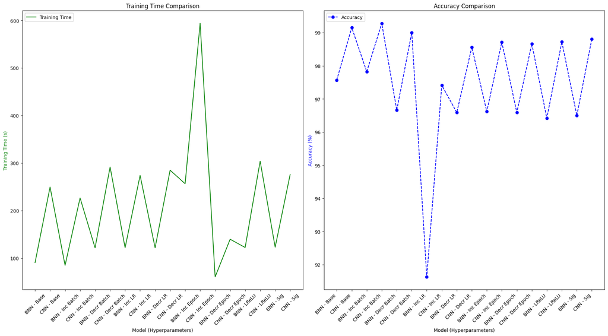

```python
plotgraph()
```

```python
class BNN(nn.Module):#simple multilayer perceptron - basic neural network
    def __init__(self):
        super(BNN, self).__init__()
        self.fc = nn.Sequential(
            nn.Linear(28*28, 128),
            nn.Tanh(),
            nn.Linear(128, 64),
            #The second layer reduces the dimensionality further from 128 to 64 neurons
            nn.Tanh(),
            nn.Linear(64, 10)
            #The final layer maps these 64 features to 10 outputs, corresponding to the
            #10 possible classes (digits 0-9) in the MNIST dataset.
        )
        #https://pytorch.org/tutorials/beginner/basics/buildmodel_tutorial.html

    def forward(self, x):
        x = x.view(x.shape[0], -1)
        #flattens the input images except for the batch dimension, making it suitable
        #for processing through fully connected layers
        return self.fc(x)

class CNN(nn.Module):
    def __init__(self):
        super(CNN, self).__init__()
        self.conv = nn.Sequential(#As shown in slides on CNN, my structure is Conv->ReLU->Pooling x2
            nn.Conv2d(1, 32, 3, 1),
            nn.Tanh(),
            nn.MaxPool2d(2),
            nn.Conv2d(32, 64, 3, 1),
            nn.Tanh(),
            nn.MaxPool2d(2)
        )
        self.fc_input_size = 5*5*64
        self.fc = nn.Sequential(
            nn.Linear(self.fc_input_size, 128),
            nn.Tanh(),
            nn.Linear(128, 10)
        )

    def forward(self, x):
        x = self.conv(x)
        x = x.view(x.size(0), -1)  # Flatten the output for the fully connected layer
        return self.fc(x)
```

```python
for model in models:
    model_name = type(model).__name__
    hyperparameter_values = "Tanh"
    print(f"Training {model_name}...")
    training_time, accuracy = train_and_evaluate(model, trainloader, testloader, device, 0.001, 10)
    store_results(model_name, hyperparameter_values, training_time, accuracy)
    print(f"{model_name} - Time: {training_time:.2f} s, Accuracy: {accuracy:.2f}%")
```

```
Training BNN...
BNN - Time: 120.31 s, Accuracy: 96.45%
Training CNN...
CNN - Time: 274.05 s, Accuracy: 98.81%
```

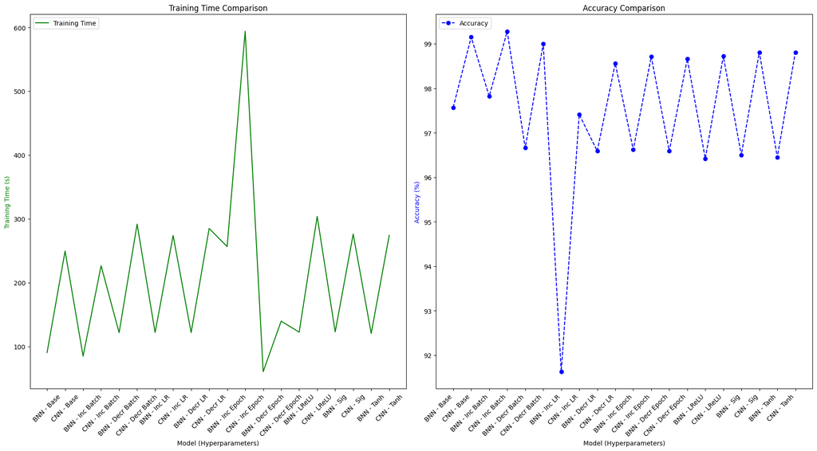

```python
plotgraph()
```

### Pros and Cons of tutorial

Pros:

- Comprehensive Coverage: The notebook provides an end-to-end tutorial covering key aspects of neural network training and evaluation, making it a solid starting point for beginners in deep learning with PyTorch.
- Practical Application: It demonstrates practical application of PyTorch libraries to a well-known problem (MNIST classification), which is excellent for hands-on learning.
- Hyperparameter Tuning: There is a clear focus on hyperparameter tuning, showcasing its impact on model performance. This is a critical skill in machine learning and is well-illustrated with examples.
- Visualization: The use of Matplotlib for visualization of results (training time and accuracy) helps in understanding model performance and is a good practice for scientific reporting.

Cons:

- Limited Architecture Exploration: The tutorial focuses on tuning external hyperparameters like batch size, learning rate, and epochs, but does not delve into architectural hyperparameters such as the number of layers, neurons, or filters within the models.
- Model Complexity: For a beginner, the jump from a basic neural network to a CNN might be steep without intermediate steps or a more gradual introduction to convolutional layers, and may not be easy to understand without the necessary prior knowledge on the topic, could also include padding to increase complexity if needed.
- Error Handling: The tutorial could benefit from including common errors or issues one might encounter when setting up deep learning models and how to resolve them.

Future Iterations:

- Expand on Model Architecture: Include sections on altering architectural parameters like the number of filters in CNNs or neurons in BNNs, explaining the impact of such changes on model capacity and overfitting/underfitting.
- Introduce Intermediate Concepts: Gradually introduce more complex models or additional layers, which can help learners better grasp the progression from simple to more complex architectures.
- Incorporate Best Practices: Discuss best practices in model evaluation, such as using a validation set and techniques like k-fold cross-validation.
- Demonstrate Regularization: Show how to implement and tune regularization methods to prevent overfitting.
- Experimentation Guidance: Provide guidelines on systematic hyperparameter tuning, perhaps through grid search or random search methodologies, and discuss the use of tools like TensorBoard for experiment tracking.

## References

https://stackoverflow.com/questions/48152674/how-do-i-check-if-pytorch-is-using-the-gpu  
https://discuss.pytorch.org/t/understanding-transform-normalize/21730  
https://www.youtube.com/watch?v=vBlO87ZAiiw&t=507s  
https://pytorch.org/tutorials/beginner/basics/buildmodel_tutorial.html  
https://pytorch.org/docs/stable/optim.html  
https://stackoverflow.com/questions/62833157/cnn-model-using-pytorch  
https://www.datacamp.com/tutorial/line-plots-in-matplotlib-with-python#:~:text=Matplotlib%20Line%20Plots%20with%20Twin%20Axes,-There%20might%20be&text=To%20create%20a%20line%20plot%20with%20twin%20axes%2C%20we%20need,axis%20as%20the%20original%20plot.  
https://sentry.io/answers/change-the-size-of-figures-drawn-with-matplotlib-in-python/#:~:text=To%20set%20the%20size%20of,width%20and%20height%20in%20inches.&text=The%20forward%3DTrue%20argument%20will,displayed%20versions%20of%20the%20figure.